# Risk Factor Analysis

## Outcome Variable

**Outcome Variable:** sstunted

## Predictor Variables

**Intervention Variable:** hhwealth_quart

**Adjustment Set:**

- arm
- sex
- W_mage
- meducyrs
- feducyrs
- W_gagebrth
- W_birthwt
- W_birthlen
- W_nchldlt5
- W_parity
- delta_W_mage
- delta_meducyrs
- delta_feducyrs
- delta_W_gagebrth
- delta_W_birthwt
- delta_W_birthlen
- delta_W_nchldlt5
- delta_W_parity

## Stratifying Variables

The analysis was stratified on these variable(s):

- agecat
- studyid
- country

## Data Summary

| agecat | studyid | country | hhwealth_quart | sstunted | n_cell | n |
| --- | --- | --- | --- | --- | --- | --- |
| Birth | ki0047075b-MAL-ED | BANGLADESH | Wealth Q4 | 0 | 21 | 82 |
| Birth | ki0047075b-MAL-ED | BANGLADESH | Wealth Q4 | 1 | 0 | 82 |
| Birth | ki0047075b-MAL-ED | BANGLADESH | Wealth Q1 | 0 | 18 | 82 |
| Birth | ki0047075b-MAL-ED | BANGLADESH | Wealth Q1 | 1 | 3 | 82 |
| Birth | ki0047075b-MAL-ED | BANGLADESH | Wealth Q2 | 0 | 19 | 82 |
| Birth | ki0047075b-MAL-ED | BANGLADESH | Wealth Q2 | 1 | 1 | 82 |
| Birth | ki0047075b-MAL-ED | BANGLADESH | Wealth Q3 | 0 | 20 | 82 |
| Birth | ki0047075b-MAL-ED | BANGLADESH | Wealth Q3 | 1 | 0 | 82 |
| Birth | ki0047075b-MAL-ED | INDIA | Wealth Q4 | 0 | 11 | 55 |
| Birth | ki0047075b-MAL-ED | INDIA | Wealth Q4 | 1 | 1 | 55 |
| Birth | ki0047075b-MAL-ED | INDIA | Wealth Q1 | 0 | 17 | 55 |
| Birth | ki0047075b-MAL-ED | INDIA | Wealth Q1 | 1 | 0 | 55 |
| Birth | ki0047075b-MAL-ED | INDIA | Wealth Q2 | 0 | 15 | 55 |
| Birth | ki0047075b-MAL-ED | INDIA | Wealth Q2 | 1 | 0 | 55 |
| Birth | ki0047075b-MAL-ED | INDIA | Wealth Q3 | 0 | 9 | 55 |
| Birth | ki0047075b-MAL-ED | INDIA | Wealth Q3 | 1 | 2 | 55 |
| Birth | ki0047075b-MAL-ED | NEPAL | Wealth Q4 | 0 | 9 | 31 |
| Birth | ki0047075b-MAL-ED | NEPAL | Wealth Q4 | 1 | 0 | 31 |
| Birth | ki0047075b-MAL-ED | NEPAL | Wealth Q1 | 0 | 8 | 31 |
| Birth | ki0047075b-MAL-ED | NEPAL | Wealth Q1 | 1 | 0 | 31 |
| Birth | ki0047075b-MAL-ED | NEPAL | Wealth Q2 | 0 | 6 | 31 |
| Birth | ki0047075b-MAL-ED | NEPAL | Wealth Q2 | 1 | 1 | 31 |
| Birth | ki0047075b-MAL-ED | NEPAL | Wealth Q3 | 0 | 7 | 31 |
| Birth | ki0047075b-MAL-ED | NEPAL | Wealth Q3 | 1 | 0 | 31 |
| Birth | ki0047075b-MAL-ED | PERU | Wealth Q4 | 0 | 10 | 36 |
| Birth | ki0047075b-MAL-ED | PERU | Wealth Q4 | 1 | 0 | 36 |
| Birth | ki0047075b-MAL-ED | PERU | Wealth Q1 | 0 | 9 | 36 |
| Birth | ki0047075b-MAL-ED | PERU | Wealth Q1 | 1 | 0 | 36 |
| Birth | ki0047075b-MAL-ED | PERU | Wealth Q2 | 0 | 9 | 36 |
| Birth | ki0047075b-MAL-ED | PERU | Wealth Q2 | 1 | 0 | 36 |

[output cut: 346 more lines]

The following strata were considered:

- agecat: 24 months, studyid: ki0047075b-MAL-ED, country: BANGLADESH
- agecat: 24 months, studyid: ki0047075b-MAL-ED, country: INDIA
- agecat: 24 months, studyid: ki0047075b-MAL-ED, country: NEPAL
- agecat: 24 months, studyid: ki0047075b-MAL-ED, country: PERU
- agecat: 24 months, studyid: ki0047075b-MAL-ED, country: SOUTH AFRICA
- agecat: 24 months, studyid: ki0047075b-MAL-ED, country: TANZANIA, UNITED REPUBLIC OF
- agecat: 24 months, studyid: ki1000108-CMC-V-BCS-2002, country: INDIA
- agecat: 24 months, studyid: ki1000108-IRC, country: INDIA
- agecat: 24 months, studyid: ki1017093b-PROVIDE, country: BANGLADESH
- agecat: 24 months, studyid: ki1066203-TanzaniaChild2, country: TANZANIA, UNITED REPUBLIC OF
- agecat: 24 months, studyid: ki1113344-GMS-Nepal, country: NEPAL
- agecat: 24 months, studyid: ki1114097-CONTENT, country: PERU
- agecat: 24 months, studyid: ki1135781-COHORTS, country: GUATEMALA
- agecat: 24 months, studyid: ki1135781-COHORTS, country: PHILIPPINES
- agecat: 24 months, studyid: ki1148112-LCNI-5, country: MALAWI
- agecat: 24 months, studyid: kiGH5241-JiVitA-3, country: BANGLADESH
- agecat: 24 months, studyid: kiGH5241-JiVitA-4, country: BANGLADESH
- agecat: 6 months, studyid: ki0047075b-MAL-ED, country: BANGLADESH
- agecat: 6 months, studyid: ki0047075b-MAL-ED, country: INDIA
- agecat: 6 months, studyid: ki0047075b-MAL-ED, country: NEPAL
- agecat: 6 months, studyid: ki0047075b-MAL-ED, country: PERU
- agecat: 6 months, studyid: ki0047075b-MAL-ED, country: SOUTH AFRICA
- agecat: 6 months, studyid: ki0047075b-MAL-ED, country: TANZANIA, UNITED REPUBLIC OF
- agecat: 6 months, studyid: ki1000108-CMC-V-BCS-2002, country: INDIA
- agecat: 6 months, studyid: ki1000108-IRC, country: INDIA
- agecat: 6 months, studyid: ki1017093b-PROVIDE, country: BANGLADESH
- agecat: 6 months, studyid: ki1066203-TanzaniaChild2, country: TANZANIA, UNITED REPUBLIC OF
- agecat: 6 months, studyid: ki1113344-GMS-Nepal, country: NEPAL
- agecat: 6 months, studyid: ki1114097-CONTENT, country: PERU
- agecat: 6 months, studyid: ki1135781-COHORTS, country: GUATEMALA
- agecat: 6 months, studyid: ki1135781-COHORTS, country: PHILIPPINES
- agecat: 6 months, studyid: ki1148112-LCNI-5, country: MALAWI
- agecat: 6 months, studyid: kiGH5241-JiVitA-3, country: BANGLADESH
- agecat: 6 months, studyid: kiGH5241-JiVitA-4, country: BANGLADESH
- agecat: Birth, studyid: ki0047075b-MAL-ED, country: BANGLADESH
- agecat: Birth, studyid: ki0047075b-MAL-ED, country: INDIA
- agecat: Birth, studyid: ki0047075b-MAL-ED, country: NEPAL
- agecat: Birth, studyid: ki0047075b-MAL-ED, country: PERU
- agecat: Birth, studyid: ki0047075b-MAL-ED, country: SOUTH AFRICA
- agecat: Birth, studyid: ki0047075b-MAL-ED, country: TANZANIA, UNITED REPUBLIC OF
- agecat: Birth, studyid: ki1000108-CMC-V-BCS-2002, country: INDIA
- agecat: Birth, studyid: ki1000108-IRC, country: INDIA
- agecat: Birth, studyid: ki1114097-CONTENT, country: PERU
- agecat: Birth, studyid: ki1135781-COHORTS, country: GUATEMALA
- agecat: Birth, studyid: ki1135781-COHORTS, country: PHILIPPINES
- agecat: Birth, studyid: kiGH5241-JiVitA-3, country: BANGLADESH
- agecat: Birth, studyid: kiGH5241-JiVitA-4, country: BANGLADESH

### Dropped Strata

Some strata were dropped due to rare outcomes:

- agecat: Birth, studyid: ki0047075b-MAL-ED, country: BANGLADESH
- agecat: Birth, studyid: ki0047075b-MAL-ED, country: INDIA
- agecat: Birth, studyid: ki0047075b-MAL-ED, country: NEPAL
- agecat: Birth, studyid: ki0047075b-MAL-ED, country: PERU
- agecat: Birth, studyid: ki0047075b-MAL-ED, country: SOUTH AFRICA
- agecat: Birth, studyid: ki0047075b-MAL-ED, country: TANZANIA, UNITED REPUBLIC OF
- agecat: Birth, studyid: ki1000108-CMC-V-BCS-2002, country: INDIA
- agecat: Birth, studyid: ki1000108-IRC, country: INDIA
- agecat: Birth, studyid: ki1114097-CONTENT, country: PERU
- agecat: Birth, studyid: ki1135781-COHORTS, country: GUATEMALA
- agecat: 6 months, studyid: ki0047075b-MAL-ED, country: BANGLADESH
- agecat: 6 months, studyid: ki0047075b-MAL-ED, country: INDIA
- agecat: 6 months, studyid: ki0047075b-MAL-ED, country: NEPAL
- agecat: 6 months, studyid: ki0047075b-MAL-ED, country: PERU
- agecat: 6 months, studyid: ki0047075b-MAL-ED, country: SOUTH AFRICA
- agecat: 6 months, studyid: ki0047075b-MAL-ED, country: TANZANIA, UNITED REPUBLIC OF
- agecat: 6 months, studyid: ki1000108-CMC-V-BCS-2002, country: INDIA
- agecat: 6 months, studyid: ki1000108-IRC, country: INDIA
- agecat: 6 months, studyid: ki1017093b-PROVIDE, country: BANGLADESH
- agecat: 6 months, studyid: ki1066203-TanzaniaChild2, country: TANZANIA, UNITED REPUBLIC OF
- agecat: 6 months, studyid: ki1113344-GMS-Nepal, country: NEPAL
- agecat: 6 months, studyid: ki1114097-CONTENT, country: PERU
- agecat: 24 months, studyid: ki0047075b-MAL-ED, country: BANGLADESH
- agecat: 24 months, studyid: ki0047075b-MAL-ED, country: INDIA
- agecat: 24 months, studyid: ki0047075b-MAL-ED, country: NEPAL
- agecat: 24 months, studyid: ki0047075b-MAL-ED, country: PERU
- agecat: 24 months, studyid: ki0047075b-MAL-ED, country: SOUTH AFRICA
- agecat: 24 months, studyid: ki0047075b-MAL-ED, country: TANZANIA, UNITED REPUBLIC OF
- agecat: 24 months, studyid: ki1066203-TanzaniaChild2, country: TANZANIA, UNITED REPUBLIC OF
- agecat: 24 months, studyid: ki1114097-CONTENT, country: PERU

## Methods Detail

We’re interested in the causal parameters $E[Y_a]$ for all values of $a \in \mathcal{A}$. These parameters represent the mean outcome if, possibly contrary to fact, we intervened to set all units to have $A=a$. Under the randomization and positivity assumptions, these are identified by the statistical parameters $\psi_a=E_W[E_{Y|A,W}(Y|A=a,W)]$. In addition, we’re interested in the mean of $Y$, $E[Y]$ under no intervention (the observed mean). We will estimate these parameters by using SuperLearner to fit the relevant likelihood factors – $E_{Y|A,W}(Y|A=a,W)$ and $p(A=a|W)$, and then updating our likelihood fit using a joint TMLE.

For unadjusted analyses ($W=\{\}$), initial likelihoods were estimated using Lrnr_glm to estimate the simple $E(Y|A)$ and Lrnr_mean to estimate $p(A)$. For adjusted analyses, a small library containing Lrnr_glmnet, Lrnr_xgboost, and Lrnr_mean was used.

Having estimated these parameters, we will then use the delta method to estimate relative risks and attributable risks relative to a prespecified baseline level of $A$.

# Results Detail

## Results Plots

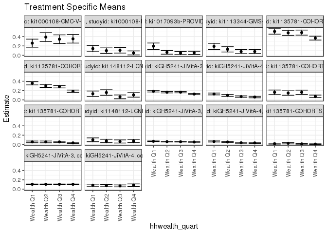

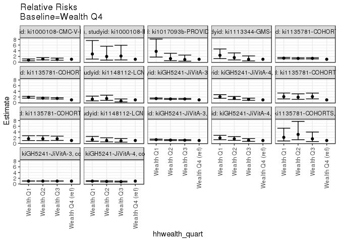

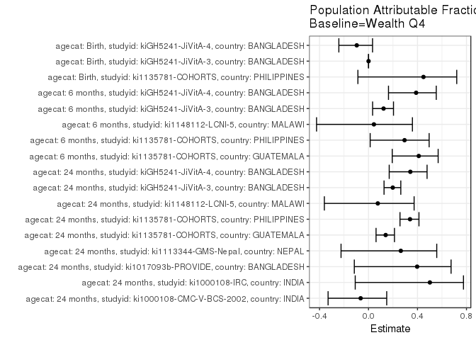

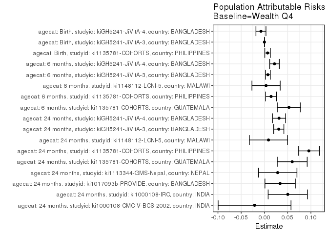

## Results Table

### Parameter: TSM

| agecat | studyid | country | intervention_level | baseline_level | estimate | ci_lower | ci_upper |
| --- | --- | --- | --- | --- | --- | --- | --- |
| Birth | ki1135781-COHORTS | PHILIPPINES | Wealth Q4 | NA | 0.0083135 | 0.0021795 | 0.0144475 |
| Birth | ki1135781-COHORTS | PHILIPPINES | Wealth Q1 | NA | 0.0174672 | 0.0076695 | 0.0272650 |
| Birth | ki1135781-COHORTS | PHILIPPINES | Wealth Q2 | NA | 0.0260223 | 0.0125676 | 0.0394771 |
| Birth | ki1135781-COHORTS | PHILIPPINES | Wealth Q3 | NA | 0.0132383 | 0.0060886 | 0.0203880 |
| Birth | kiGH5241-JiVitA-3 | BANGLADESH | Wealth Q4 | NA | 0.1041188 | 0.0994458 | 0.1087917 |
| Birth | kiGH5241-JiVitA-3 | BANGLADESH | Wealth Q1 | NA | 0.1041589 | 0.0994848 | 0.1088331 |
| Birth | kiGH5241-JiVitA-3 | BANGLADESH | Wealth Q2 | NA | 0.1041563 | 0.0994823 | 0.1088303 |
| Birth | kiGH5241-JiVitA-3 | BANGLADESH | Wealth Q3 | NA | 0.1041558 | 0.0994813 | 0.1088302 |
| Birth | kiGH5241-JiVitA-4 | BANGLADESH | Wealth Q4 | NA | 0.0853312 | 0.0595506 | 0.1111118 |
| Birth | kiGH5241-JiVitA-4 | BANGLADESH | Wealth Q1 | NA | 0.0843466 | 0.0617153 | 0.1069778 |
| Birth | kiGH5241-JiVitA-4 | BANGLADESH | Wealth Q2 | NA | 0.0751035 | 0.0503521 | 0.0998548 |
| Birth | kiGH5241-JiVitA-4 | BANGLADESH | Wealth Q3 | NA | 0.0688966 | 0.0483295 | 0.0894637 |
| 6 months | ki1135781-COHORTS | GUATEMALA | Wealth Q4 | NA | 0.0758617 | 0.0486604 | 0.1030629 |
| 6 months | ki1135781-COHORTS | GUATEMALA | Wealth Q1 | NA | 0.1621048 | 0.1126120 | 0.2115977 |
| 6 months | ki1135781-COHORTS | GUATEMALA | Wealth Q2 | NA | 0.1464157 | 0.0990620 | 0.1937694 |
| 6 months | ki1135781-COHORTS | GUATEMALA | Wealth Q3 | NA | 0.1626981 | 0.1157109 | 0.2096853 |
| 6 months | ki1135781-COHORTS | PHILIPPINES | Wealth Q4 | NA | 0.0343966 | 0.0216564 | 0.0471367 |
| 6 months | ki1135781-COHORTS | PHILIPPINES | Wealth Q1 | NA | 0.0559353 | 0.0378963 | 0.0739743 |
| 6 months | ki1135781-COHORTS | PHILIPPINES | Wealth Q2 | NA | 0.0554315 | 0.0363701 | 0.0744928 |
| 6 months | ki1135781-COHORTS | PHILIPPINES | Wealth Q3 | NA | 0.0552407 | 0.0408059 | 0.0696754 |
| 6 months | ki1148112-LCNI-5 | MALAWI | Wealth Q4 | NA | 0.0761338 | 0.0410239 | 0.1112436 |
| 6 months | ki1148112-LCNI-5 | MALAWI | Wealth Q1 | NA | 0.1006738 | 0.0597253 | 0.1416222 |
| 6 months | ki1148112-LCNI-5 | MALAWI | Wealth Q2 | NA | 0.0757633 | 0.0391190 | 0.1124076 |
| 6 months | ki1148112-LCNI-5 | MALAWI | Wealth Q3 | NA | 0.0648842 | 0.0310943 | 0.0986741 |
| 6 months | kiGH5241-JiVitA-3 | BANGLADESH | Wealth Q4 | NA | 0.0531795 | 0.0470882 | 0.0592709 |
| 6 months | kiGH5241-JiVitA-3 | BANGLADESH | Wealth Q1 | NA | 0.0685533 | 0.0616195 | 0.0754871 |
| 6 months | kiGH5241-JiVitA-3 | BANGLADESH | Wealth Q2 | NA | 0.0609500 | 0.0544653 | 0.0674347 |
| 6 months | kiGH5241-JiVitA-3 | BANGLADESH | Wealth Q3 | NA | 0.0588070 | 0.0528240 | 0.0647901 |
| 6 months | kiGH5241-JiVitA-4 | BANGLADESH | Wealth Q4 | NA | 0.0340622 | 0.0216351 | 0.0464893 |
| 6 months | kiGH5241-JiVitA-4 | BANGLADESH | Wealth Q1 | NA | 0.0645458 | 0.0529729 | 0.0761188 |
| 6 months | kiGH5241-JiVitA-4 | BANGLADESH | Wealth Q2 | NA | 0.0537344 | 0.0418875 | 0.0655814 |
| 6 months | kiGH5241-JiVitA-4 | BANGLADESH | Wealth Q3 | NA | 0.0368127 | 0.0264991 | 0.0471263 |
| 24 months | ki1000108-CMC-V-BCS-2002 | INDIA | Wealth Q4 | NA | 0.3518352 | 0.2605501 | 0.4431203 |
| 24 months | ki1000108-CMC-V-BCS-2002 | INDIA | Wealth Q1 | NA | 0.2585865 | 0.1723307 | 0.3448423 |
| 24 months | ki1000108-CMC-V-BCS-2002 | INDIA | Wealth Q2 | NA | 0.3884476 | 0.2946032 | 0.4822920 |
| 24 months | ki1000108-CMC-V-BCS-2002 | INDIA | Wealth Q3 | NA | 0.3435342 | 0.2504713 | 0.4365971 |
| 24 months | ki1000108-IRC | INDIA | Wealth Q4 | NA | 0.0500000 | 0.0072313 | 0.0927687 |
| 24 months | ki1000108-IRC | INDIA | Wealth Q1 | NA | 0.1428571 | 0.0758436 | 0.2098707 |
| 24 months | ki1000108-IRC | INDIA | Wealth Q2 | NA | 0.0990099 | 0.0406898 | 0.1573300 |
| 24 months | ki1000108-IRC | INDIA | Wealth Q3 | NA | 0.1067961 | 0.0470769 | 0.1665153 |
| 24 months | ki1017093b-PROVIDE | BANGLADESH | Wealth Q4 | NA | 0.0512821 | 0.0166391 | 0.0859250 |
| 24 months | ki1017093b-PROVIDE | BANGLADESH | Wealth Q1 | NA | 0.1937984 | 0.1255288 | 0.2620681 |
| 24 months | ki1017093b-PROVIDE | BANGLADESH | Wealth Q2 | NA | 0.0633803 | 0.0232715 | 0.1034891 |
| 24 months | ki1017093b-PROVIDE | BANGLADESH | Wealth Q3 | NA | 0.0469799 | 0.0129751 | 0.0809846 |
| 24 months | ki1113344-GMS-Nepal | NEPAL | Wealth Q4 | NA | 0.0796716 | 0.0351625 | 0.1241806 |
| 24 months | ki1113344-GMS-Nepal | NEPAL | Wealth Q1 | NA | 0.1906744 | 0.1254206 | 0.2559283 |
| 24 months | ki1113344-GMS-Nepal | NEPAL | Wealth Q2 | NA | 0.1263210 | 0.0700781 | 0.1825638 |
| 24 months | ki1113344-GMS-Nepal | NEPAL | Wealth Q3 | NA | 0.0780432 | 0.0334148 | 0.1226716 |
| 24 months | ki1135781-COHORTS | GUATEMALA | Wealth Q4 | NA | 0.3669923 | 0.3250103 | 0.4089743 |
| 24 months | ki1135781-COHORTS | GUATEMALA | Wealth Q1 | NA | 0.5094504 | 0.4520133 | 0.5668874 |
| 24 months | ki1135781-COHORTS | GUATEMALA | Wealth Q2 | NA | 0.4801411 | 0.4252478 | 0.5350344 |
| 24 months | ki1135781-COHORTS | GUATEMALA | Wealth Q3 | NA | 0.4851137 | 0.4310980 | 0.5391295 |
| 24 months | ki1135781-COHORTS | PHILIPPINES | Wealth Q4 | NA | 0.1862559 | 0.1616010 | 0.2109108 |
| 24 months | ki1135781-COHORTS | PHILIPPINES | Wealth Q1 | NA | 0.3550754 | 0.3201282 | 0.3900227 |
| 24 months | ki1135781-COHORTS | PHILIPPINES | Wealth Q2 | NA | 0.2987137 | 0.2644834 | 0.3329441 |
| 24 months | ki1135781-COHORTS | PHILIPPINES | Wealth Q3 | NA | 0.2830448 | 0.2559722 | 0.3101175 |
| 24 months | ki1148112-LCNI-5 | MALAWI | Wealth Q4 | NA | 0.1062500 | 0.0584598 | 0.1540402 |
| 24 months | ki1148112-LCNI-5 | MALAWI | Wealth Q1 | NA | 0.1317829 | 0.0733611 | 0.1902048 |
| 24 months | ki1148112-LCNI-5 | MALAWI | Wealth Q2 | NA | 0.1575342 | 0.0983898 | 0.2166787 |
| 24 months | ki1148112-LCNI-5 | MALAWI | Wealth Q3 | NA | 0.0647482 | 0.0238035 | 0.1056929 |
| 24 months | kiGH5241-JiVitA-3 | BANGLADESH | Wealth Q4 | NA | 0.1248739 | 0.1126828 | 0.1370650 |
| 24 months | kiGH5241-JiVitA-3 | BANGLADESH | Wealth Q1 | NA | 0.1836801 | 0.1695059 | 0.1978543 |
| 24 months | kiGH5241-JiVitA-3 | BANGLADESH | Wealth Q2 | NA | 0.1641369 | 0.1493115 | 0.1789623 |
| 24 months | kiGH5241-JiVitA-3 | BANGLADESH | Wealth Q3 | NA | 0.1650720 | 0.1509106 | 0.1792334 |
| 24 months | kiGH5241-JiVitA-4 | BANGLADESH | Wealth Q4 | NA | 0.0605888 | 0.0446729 | 0.0765047 |
| 24 months | kiGH5241-JiVitA-4 | BANGLADESH | Wealth Q1 | NA | 0.1270989 | 0.1073822 | 0.1468156 |
| 24 months | kiGH5241-JiVitA-4 | BANGLADESH | Wealth Q2 | NA | 0.0954257 | 0.0757561 | 0.1150953 |
| 24 months | kiGH5241-JiVitA-4 | BANGLADESH | Wealth Q3 | NA | 0.0709614 | 0.0560213 | 0.0859015 |

### Parameter: E(Y)

| agecat | studyid | country | intervention_level | baseline_level | estimate | ci_lower | ci_upper |
| --- | --- | --- | --- | --- | --- | --- | --- |
| Birth | ki1135781-COHORTS | PHILIPPINES | NA | NA | 0.0150869 | 0.0107594 | 0.0194144 |
| Birth | kiGH5241-JiVitA-3 | BANGLADESH | NA | NA | 0.1041645 | 0.0994900 | 0.1088391 |
| Birth | kiGH5241-JiVitA-4 | BANGLADESH | NA | NA | 0.0778589 | 0.0559066 | 0.0998111 |
| 6 months | ki1135781-COHORTS | GUATEMALA | NA | NA | 0.1286486 | 0.1070607 | 0.1502366 |
| 6 months | ki1135781-COHORTS | PHILIPPINES | NA | NA | 0.0487445 | 0.0406327 | 0.0568562 |
| 6 months | ki1148112-LCNI-5 | MALAWI | NA | NA | 0.0796569 | 0.0610679 | 0.0982459 |
| 6 months | kiGH5241-JiVitA-3 | BANGLADESH | NA | NA | 0.0606359 | 0.0567797 | 0.0644920 |
| 6 months | kiGH5241-JiVitA-4 | BANGLADESH | NA | NA | 0.0557144 | 0.0488132 | 0.0626157 |
| 24 months | ki1000108-CMC-V-BCS-2002 | INDIA | NA | NA | 0.3306452 | 0.2827744 | 0.3785159 |
| 24 months | ki1000108-IRC | INDIA | NA | NA | 0.1002445 | 0.0711031 | 0.1293859 |
| 24 months | ki1017093b-PROVIDE | BANGLADESH | NA | NA | 0.0850694 | 0.0622663 | 0.1078726 |
| 24 months | ki1113344-GMS-Nepal | NEPAL | NA | NA | 0.1082164 | 0.0809323 | 0.1355005 |
| 24 months | ki1135781-COHORTS | GUATEMALA | NA | NA | 0.4267823 | 0.3966784 | 0.4568861 |
| 24 months | ki1135781-COHORTS | PHILIPPINES | NA | NA | 0.2817996 | 0.2639639 | 0.2996353 |
| 24 months | ki1148112-LCNI-5 | MALAWI | NA | NA | 0.1149826 | 0.0888632 | 0.1411019 |
| 24 months | kiGH5241-JiVitA-3 | BANGLADESH | NA | NA | 0.1557415 | 0.1469948 | 0.1644882 |
| 24 months | kiGH5241-JiVitA-4 | BANGLADESH | NA | NA | 0.0920173 | 0.0825478 | 0.1014867 |

### Parameter: RR

| agecat | studyid | country | intervention_level | baseline_level | estimate | ci_lower | ci_upper |
| --- | --- | --- | --- | --- | --- | --- | --- |
| Birth | ki1135781-COHORTS | PHILIPPINES | Wealth Q4 | Wealth Q4 | 1.0000000 | 1.0000000 | 1.0000000 |
| Birth | ki1135781-COHORTS | PHILIPPINES | Wealth Q1 | Wealth Q4 | 2.1010605 | 0.8316064 | 5.3083471 |
| Birth | ki1135781-COHORTS | PHILIPPINES | Wealth Q2 | Wealth Q4 | 3.1301115 | 1.2713841 | 7.7062457 |
| Birth | ki1135781-COHORTS | PHILIPPINES | Wealth Q3 | Wealth Q4 | 1.5923771 | 0.6381739 | 3.9733128 |
| Birth | kiGH5241-JiVitA-3 | BANGLADESH | Wealth Q4 | Wealth Q4 | 1.0000000 | 1.0000000 | 1.0000000 |
| Birth | kiGH5241-JiVitA-3 | BANGLADESH | Wealth Q1 | Wealth Q4 | 1.0003860 | 1.0002819 | 1.0004900 |
| Birth | kiGH5241-JiVitA-3 | BANGLADESH | Wealth Q2 | Wealth Q4 | 1.0003605 | 1.0002569 | 1.0004640 |
| Birth | kiGH5241-JiVitA-3 | BANGLADESH | Wealth Q3 | Wealth Q4 | 1.0003557 | 1.0002522 | 1.0004592 |
| Birth | kiGH5241-JiVitA-4 | BANGLADESH | Wealth Q4 | Wealth Q4 | 1.0000000 | 1.0000000 | 1.0000000 |
| Birth | kiGH5241-JiVitA-4 | BANGLADESH | Wealth Q1 | Wealth Q4 | 0.9884610 | 0.8629714 | 1.1321988 |
| Birth | kiGH5241-JiVitA-4 | BANGLADESH | Wealth Q2 | Wealth Q4 | 0.8801407 | 0.7072213 | 1.0953399 |
| Birth | kiGH5241-JiVitA-4 | BANGLADESH | Wealth Q3 | Wealth Q4 | 0.8074014 | 0.6589963 | 0.9892271 |
| 6 months | ki1135781-COHORTS | GUATEMALA | Wealth Q4 | Wealth Q4 | 1.0000000 | 1.0000000 | 1.0000000 |
| 6 months | ki1135781-COHORTS | GUATEMALA | Wealth Q1 | Wealth Q4 | 2.1368482 | 1.3383385 | 3.4117826 |
| 6 months | ki1135781-COHORTS | GUATEMALA | Wealth Q2 | Wealth Q4 | 1.9300362 | 1.1922318 | 3.1244257 |
| 6 months | ki1135781-COHORTS | GUATEMALA | Wealth Q3 | Wealth Q4 | 2.1446688 | 1.3553822 | 3.3935847 |
| 6 months | ki1135781-COHORTS | PHILIPPINES | Wealth Q4 | Wealth Q4 | 1.0000000 | 1.0000000 | 1.0000000 |
| 6 months | ki1135781-COHORTS | PHILIPPINES | Wealth Q1 | Wealth Q4 | 1.6261901 | 0.9958110 | 2.6556188 |
| 6 months | ki1135781-COHORTS | PHILIPPINES | Wealth Q2 | Wealth Q4 | 1.6115415 | 0.9728249 | 2.6696131 |
| 6 months | ki1135781-COHORTS | PHILIPPINES | Wealth Q3 | Wealth Q4 | 1.6059941 | 1.0211422 | 2.5258159 |
| 6 months | ki1148112-LCNI-5 | MALAWI | Wealth Q4 | Wealth Q4 | 1.0000000 | 1.0000000 | 1.0000000 |
| 6 months | ki1148112-LCNI-5 | MALAWI | Wealth Q1 | Wealth Q4 | 1.3223271 | 0.7163506 | 2.4409121 |
| 6 months | ki1148112-LCNI-5 | MALAWI | Wealth Q2 | Wealth Q4 | 0.9951339 | 0.5107823 | 1.9387742 |
| 6 months | ki1148112-LCNI-5 | MALAWI | Wealth Q3 | Wealth Q4 | 0.8522395 | 0.4262559 | 1.7039346 |
| 6 months | kiGH5241-JiVitA-3 | BANGLADESH | Wealth Q4 | Wealth Q4 | 1.0000000 | 1.0000000 | 1.0000000 |
| 6 months | kiGH5241-JiVitA-3 | BANGLADESH | Wealth Q1 | Wealth Q4 | 1.2890914 | 1.1186895 | 1.4854494 |
| 6 months | kiGH5241-JiVitA-3 | BANGLADESH | Wealth Q2 | Wealth Q4 | 1.1461174 | 0.9874959 | 1.3302183 |
| 6 months | kiGH5241-JiVitA-3 | BANGLADESH | Wealth Q3 | Wealth Q4 | 1.1058208 | 0.9544616 | 1.2811827 |
| 6 months | kiGH5241-JiVitA-4 | BANGLADESH | Wealth Q4 | Wealth Q4 | 1.0000000 | 1.0000000 | 1.0000000 |
| 6 months | kiGH5241-JiVitA-4 | BANGLADESH | Wealth Q1 | Wealth Q4 | 1.8949429 | 1.2789651 | 2.8075892 |
| 6 months | kiGH5241-JiVitA-4 | BANGLADESH | Wealth Q2 | Wealth Q4 | 1.5775408 | 1.0427494 | 2.3866088 |
| 6 months | kiGH5241-JiVitA-4 | BANGLADESH | Wealth Q3 | Wealth Q4 | 1.0807503 | 0.6901861 | 1.6923281 |
| 24 months | ki1000108-CMC-V-BCS-2002 | INDIA | Wealth Q4 | Wealth Q4 | 1.0000000 | 1.0000000 | 1.0000000 |
| 24 months | ki1000108-CMC-V-BCS-2002 | INDIA | Wealth Q1 | Wealth Q4 | 0.7349649 | 0.4817826 | 1.1211974 |
| 24 months | ki1000108-CMC-V-BCS-2002 | INDIA | Wealth Q2 | Wealth Q4 | 1.1040612 | 0.7750756 | 1.5726869 |
| 24 months | ki1000108-CMC-V-BCS-2002 | INDIA | Wealth Q3 | Wealth Q4 | 0.9764066 | 0.6714298 | 1.4199100 |
| 24 months | ki1000108-IRC | INDIA | Wealth Q4 | Wealth Q4 | 1.0000000 | 1.0000000 | 1.0000000 |
| 24 months | ki1000108-IRC | INDIA | Wealth Q1 | Wealth Q4 | 2.8571428 | 1.0770898 | 7.5790015 |
| 24 months | ki1000108-IRC | INDIA | Wealth Q2 | Wealth Q4 | 1.9801980 | 0.7009124 | 5.5943998 |
| 24 months | ki1000108-IRC | INDIA | Wealth Q3 | Wealth Q4 | 2.1359223 | 0.7687111 | 5.9348225 |
| 24 months | ki1017093b-PROVIDE | BANGLADESH | Wealth Q4 | Wealth Q4 | 1.0000000 | 1.0000000 | 1.0000000 |
| 24 months | ki1017093b-PROVIDE | BANGLADESH | Wealth Q1 | Wealth Q4 | 3.7790698 | 1.7640433 | 8.0958149 |
| 24 months | ki1017093b-PROVIDE | BANGLADESH | Wealth Q2 | Wealth Q4 | 1.2359155 | 0.4897626 | 3.1188316 |
| 24 months | ki1017093b-PROVIDE | BANGLADESH | Wealth Q3 | Wealth Q4 | 0.9161074 | 0.3403771 | 2.4656561 |
| 24 months | ki1113344-GMS-Nepal | NEPAL | Wealth Q4 | Wealth Q4 | 1.0000000 | 1.0000000 | 1.0000000 |
| 24 months | ki1113344-GMS-Nepal | NEPAL | Wealth Q1 | Wealth Q4 | 2.3932561 | 1.2421356 | 4.6111509 |
| 24 months | ki1113344-GMS-Nepal | NEPAL | Wealth Q2 | Wealth Q4 | 1.5855214 | 0.7777228 | 3.2323576 |
| 24 months | ki1113344-GMS-Nepal | NEPAL | Wealth Q3 | Wealth Q4 | 0.9795619 | 0.4400590 | 2.1804836 |
| 24 months | ki1135781-COHORTS | GUATEMALA | Wealth Q4 | Wealth Q4 | 1.0000000 | 1.0000000 | 1.0000000 |
| 24 months | ki1135781-COHORTS | GUATEMALA | Wealth Q1 | Wealth Q4 | 1.3881773 | 1.1887234 | 1.6210972 |
| 24 months | ki1135781-COHORTS | GUATEMALA | Wealth Q2 | Wealth Q4 | 1.3083139 | 1.1194683 | 1.5290163 |
| 24 months | ki1135781-COHORTS | GUATEMALA | Wealth Q3 | Wealth Q4 | 1.3218636 | 1.1332771 | 1.5418324 |
| 24 months | ki1135781-COHORTS | PHILIPPINES | Wealth Q4 | Wealth Q4 | 1.0000000 | 1.0000000 | 1.0000000 |
| 24 months | ki1135781-COHORTS | PHILIPPINES | Wealth Q1 | Wealth Q4 | 1.9063852 | 1.6210053 | 2.2420065 |
| 24 months | ki1135781-COHORTS | PHILIPPINES | Wealth Q2 | Wealth Q4 | 1.6037816 | 1.3510044 | 1.9038542 |
| 24 months | ki1135781-COHORTS | PHILIPPINES | Wealth Q3 | Wealth Q4 | 1.5196559 | 1.2954140 | 1.7827151 |
| 24 months | ki1148112-LCNI-5 | MALAWI | Wealth Q4 | Wealth Q4 | 1.0000000 | 1.0000000 | 1.0000000 |
| 24 months | ki1148112-LCNI-5 | MALAWI | Wealth Q1 | Wealth Q4 | 1.2403101 | 0.6595622 | 2.3324095 |
| 24 months | ki1148112-LCNI-5 | MALAWI | Wealth Q2 | Wealth Q4 | 1.4826753 | 0.8252733 | 2.6637552 |
| 24 months | ki1148112-LCNI-5 | MALAWI | Wealth Q3 | Wealth Q4 | 0.6093948 | 0.2804655 | 1.3240920 |
| 24 months | kiGH5241-JiVitA-3 | BANGLADESH | Wealth Q4 | Wealth Q4 | 1.0000000 | 1.0000000 | 1.0000000 |
| 24 months | kiGH5241-JiVitA-3 | BANGLADESH | Wealth Q1 | Wealth Q4 | 1.4709246 | 1.3084269 | 1.6536034 |
| 24 months | kiGH5241-JiVitA-3 | BANGLADESH | Wealth Q2 | Wealth Q4 | 1.3144216 | 1.1593695 | 1.4902100 |
| 24 months | kiGH5241-JiVitA-3 | BANGLADESH | Wealth Q3 | Wealth Q4 | 1.3219098 | 1.1661744 | 1.4984427 |
| 24 months | kiGH5241-JiVitA-4 | BANGLADESH | Wealth Q4 | Wealth Q4 | 1.0000000 | 1.0000000 | 1.0000000 |
| 24 months | kiGH5241-JiVitA-4 | BANGLADESH | Wealth Q1 | Wealth Q4 | 2.0977290 | 1.5495958 | 2.8397513 |
| 24 months | kiGH5241-JiVitA-4 | BANGLADESH | Wealth Q2 | Wealth Q4 | 1.5749727 | 1.1234328 | 2.2079995 |
| 24 months | kiGH5241-JiVitA-4 | BANGLADESH | Wealth Q3 | Wealth Q4 | 1.1711964 | 0.8516401 | 1.6106581 |

### Parameter: PAR

| agecat | studyid | country | intervention_level | baseline_level | estimate | ci_lower | ci_upper |
| --- | --- | --- | --- | --- | --- | --- | --- |
| Birth | ki1135781-COHORTS | PHILIPPINES | Wealth Q4 | NA | 0.0067734 | 0.0008091 | 0.0127376 |
| Birth | kiGH5241-JiVitA-3 | BANGLADESH | Wealth Q4 | NA | 0.0000458 | 0.0000369 | 0.0000546 |
| Birth | kiGH5241-JiVitA-4 | BANGLADESH | Wealth Q4 | NA | -0.0074724 | -0.0182481 | 0.0033034 |
| 6 months | ki1135781-COHORTS | GUATEMALA | Wealth Q4 | NA | 0.0527870 | 0.0276574 | 0.0779166 |
| 6 months | ki1135781-COHORTS | PHILIPPINES | Wealth Q4 | NA | 0.0143479 | 0.0025256 | 0.0261702 |
| 6 months | ki1148112-LCNI-5 | MALAWI | Wealth Q4 | NA | 0.0035231 | -0.0268601 | 0.0339063 |
| 6 months | kiGH5241-JiVitA-3 | BANGLADESH | Wealth Q4 | NA | 0.0074563 | 0.0022585 | 0.0126541 |
| 6 months | kiGH5241-JiVitA-4 | BANGLADESH | Wealth Q4 | NA | 0.0216523 | 0.0112927 | 0.0320118 |
| 24 months | ki1000108-CMC-V-BCS-2002 | INDIA | Wealth Q4 | NA | -0.0211901 | -0.0995860 | 0.0572059 |
| 24 months | ki1000108-IRC | INDIA | Wealth Q4 | NA | 0.0502445 | 0.0080079 | 0.0924811 |
| 24 months | ki1017093b-PROVIDE | BANGLADESH | Wealth Q4 | NA | 0.0337874 | 0.0010759 | 0.0664989 |
| 24 months | ki1113344-GMS-Nepal | NEPAL | Wealth Q4 | NA | 0.0285449 | -0.0128895 | 0.0699793 |
| 24 months | ki1135781-COHORTS | GUATEMALA | Wealth Q4 | NA | 0.0597900 | 0.0276131 | 0.0919669 |
| 24 months | ki1135781-COHORTS | PHILIPPINES | Wealth Q4 | NA | 0.0955437 | 0.0728936 | 0.1181938 |
| 24 months | ki1148112-LCNI-5 | MALAWI | Wealth Q4 | NA | 0.0087326 | -0.0324119 | 0.0498771 |
| 24 months | kiGH5241-JiVitA-3 | BANGLADESH | Wealth Q4 | NA | 0.0308676 | 0.0199263 | 0.0418089 |
| 24 months | kiGH5241-JiVitA-4 | BANGLADESH | Wealth Q4 | NA | 0.0314285 | 0.0172540 | 0.0456029 |

### Parameter: PAF

| agecat | studyid | country | intervention_level | baseline_level | estimate | ci_lower | ci_upper |
| --- | --- | --- | --- | --- | --- | --- | --- |
| Birth | ki1135781-COHORTS | PHILIPPINES | Wealth Q4 | NA | 0.4489569 | -0.0865616 | 0.7205419 |
| Birth | kiGH5241-JiVitA-3 | BANGLADESH | Wealth Q4 | NA | 0.0004395 | 0.0003560 | 0.0005230 |
| Birth | kiGH5241-JiVitA-4 | BANGLADESH | Wealth Q4 | NA | -0.0959730 | -0.2421662 | 0.0330144 |
| 6 months | ki1135781-COHORTS | GUATEMALA | Wealth Q4 | NA | 0.4103191 | 0.1937316 | 0.5687248 |
| 6 months | ki1135781-COHORTS | PHILIPPINES | Wealth Q4 | NA | 0.2943495 | 0.0135940 | 0.4951951 |
| 6 months | ki1148112-LCNI-5 | MALAWI | Wealth Q4 | NA | 0.0442282 | -0.4242451 | 0.3586079 |
| 6 months | kiGH5241-JiVitA-3 | BANGLADESH | Wealth Q4 | NA | 0.1229687 | 0.0335560 | 0.2041092 |
| 6 months | kiGH5241-JiVitA-4 | BANGLADESH | Wealth Q4 | NA | 0.3886296 | 0.1631938 | 0.5533329 |
| 24 months | ki1000108-CMC-V-BCS-2002 | INDIA | Wealth Q4 | NA | -0.0640870 | -0.3300669 | 0.1487037 |
| 24 months | ki1000108-IRC | INDIA | Wealth Q4 | NA | 0.5012195 | -0.1084738 | 0.7755635 |
| 24 months | ki1017093b-PROVIDE | BANGLADESH | Wealth Q4 | NA | 0.3971743 | -0.1158955 | 0.6743433 |
| 24 months | ki1113344-GMS-Nepal | NEPAL | Wealth Q4 | NA | 0.2637758 | -0.2243118 | 0.5572810 |
| 24 months | ki1135781-COHORTS | GUATEMALA | Wealth Q4 | NA | 0.1400948 | 0.0615875 | 0.2120343 |
| 24 months | ki1135781-COHORTS | PHILIPPINES | Wealth Q4 | NA | 0.3390485 | 0.2571027 | 0.4119552 |
| 24 months | ki1148112-LCNI-5 | MALAWI | Wealth Q4 | NA | 0.0759470 | -0.3605846 | 0.3724212 |
| 24 months | kiGH5241-JiVitA-3 | BANGLADESH | Wealth Q4 | NA | 0.1981978 | 0.1268599 | 0.2637073 |
| 24 months | kiGH5241-JiVitA-4 | BANGLADESH | Wealth Q4 | NA | 0.3415496 | 0.1690999 | 0.4782081 |